# Bitcoin's Performance and Network Valuation

In this post, we will analyze the historical data of Bitcoin and explore the fundamental factors driving the market's valuation of the Bitcoin network.

### Introduction to Bitcoin

Bitcoin is the world's first decentralized digital currency and a peer-to-peer form of electronic cash. It allows online payments to be sent directly from one party anonymously to another without going through a third-party intermediary like a bank. The infrastructure that makes up the backbone of Bitcoin is the **blockchain**, which can be thought of as unalterable database of every transaction that has transpired in the Bitcoin network. Bitcoin is *decentralized* because the same copy of the blockchain exists in all the connected computers across the network. And as all the transactions are publicly available for anyone to look up, no single authority or third-party needs to be trusted.

From an investment perspective, Bitcoin can be thought of as a form of digital gold, a means to store value. Similar to physical gold, Bitcoin has a limited supply (only 21 million Bitcoins would ever be circulated) and is hard to counterfeit. As with gold, Bitcoin also required work, computational work in its case, to release new coins from their source.

However, there is a major distinction between gold and Bitcoin: Each ingot of gold has always existed independently of every other ingot. Bitcoins, on the other hand, were designed to exist inside a decentralized network, just as all the websites in the world exist only within the decentralized web of the Internet. As such, Bitcoin should be valued as a network.

### Bitcoin's Performance vs. the Global Markets

In this section, we will look at the price performance of the major cryptocurrencies: Bitcoin and Ethereum.

Let's load the relevant modules and libraries to begin our data exploration. We will be using Pandas for the data analysis, Matplotlib for the plotting, Plotly and Seaborn for the data visualization, and the Pandas DataReader and Quandl API to import the data live.

```python
import datetime as dt
import pandas as pd
import matplotlib.pyplot as plt
% matplotlib inline
import seaborn as sns
import cufflinks as cf
from plotly.offline import *
init_notebook_mode(connected = True)
cf.go_offline()
import plotly.graph_objs as go
from pandas_datareader import data
import quandl
from quandl_key import *  # for the API key
quandl.ApiConfig.api_key = QUANDL_API_Key
```

Let's retrieve the historical price data for Bitcoin and Ethereum.

```python
# Bitcoin prices in USD (source: Blockchain.info)
URL = 'https://api.blockchain.info/charts/market-price?timespan=all&format=csv'
asset_prices = pd.read_csv(URL, index_col = 'Date', names = ['Date', 'Bitcoin'], parse_dates = ['Date'])

# Ethereum prices in USD (source: GDAX)
ethereum_price = quandl.get('GDAX/ETH_USD.1')
ethereum_price.columns = ['Ethereum']
asset_prices = pd.concat([asset_prices, ethereum_price], axis = 1)

# Let's limit our analysis to the past five years.
asset_prices = asset_prices.loc[asset_prices.index > pd.Timestamp(2013, 1, 1)]

# We want to fill in any missing data with the last known prices.
asset_prices.fillna(method = 'ffill', inplace = True)
```

Then we'll plot a line chart to view the recent performance of the digital currencies.

```python
layout = go.Layout(title = 'Price Performance of Major Digital Currencies', titlefont = dict(size = 22), yaxis = dict(
    type = 'log', tickformat = '$,.2r'))
asset_prices.iplot(layout = layout)
```

[interactive chart not shown]

Investors will be interested in comparing the performance of cryptocurrencies to other assets in the global markets. To take a look at this comparison, let's import the historical data for the Euro, gold and the S&P 500 index.

```python
# Euro exchange rate in USD (source: ECB)
euro_price = quandl.get('ECB/EURUSD.1')
euro_price.columns = ['Euro']
asset_prices = pd.concat([asset_prices, euro_price], axis = 1)

# Gold prices in USD (source: World Gold Council)
gold_price = quandl.get('WGC/GOLD_DAILY_USD.1')
gold_price.columns = ['Gold']
asset_prices = pd.concat([asset_prices, gold_price], axis = 1)

# S&P 500 prices in USD (source: Yahoo Finance)
sp500_price = data.DataReader('^GSPC', data_source = 'yahoo')
sp500_price = sp500_price['Adj Close']
sp500_price.rename('S&P 500 Index', inplace = True)
asset_prices = pd.concat([asset_prices, sp500_price], axis = 1)

# We will fill in any missing data with the last known values.
asset_prices.fillna(method = 'ffill', inplace = True)
```

Investors will want to know how their cryptocurrency investments will correlate with other assets they may be holding. The lower the correlation that cryptocurrencies have with other assets, the greater the diversification investors can achieve by investing in cryptoassets.

```
Text(0.43,0.95,'(Values represent Pearson correlation coefficient)')
```

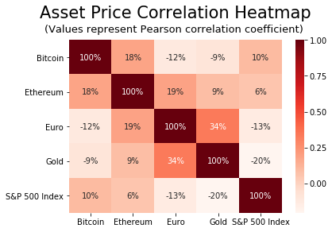

```python
# Let's take a look at the most recent year (2017).
asset_prices_2017 = asset_prices.loc[asset_prices.index.year == 2017]

# We'll create a correlation matrix of the daily returns and plot that using a heat map to visualize the correlations.
sns.heatmap(asset_prices_2017.pct_change(periods = 7).corr(), annot = True, cmap ='Reds', fmt = '.0%')
plt.title(x = 0.5, y = 1.1, s = 'Asset Price Correlation Heatmap', fontsize = 21)
plt.suptitle(x = 0.43, y = 0.95, t = '(Values represent Pearson correlation coefficient)', fontsize = 13)
```

## Valuation of the Bitcoin Network

In fall 2009, when the first Bitcoin trades took place, the exchange NewLibertyStandard came up with its own method for valuing a Bitcoin: Using the rough cost of electricity needed to generate a coin (calculated using the exchange's own electricity bill). By this measure, one dollar was worth around 1,000 Bitcoins in late 2009.

As more people used Bitcoin, it only makes sense to base its valuation on its network attributes. In this section, we model the market valuation of the Bitcoin network using **Metcalfe's Law**.

Named after Robert Metcalfe, the inventor of the Ethernet, Metcalfe's Law states that if there are *n* members on a network, the value of the network is proportional to *n<sup>2</sup>*. We can use the **number of unique Bitcoin addresses** as a proxy for the number of members on the Bitcoin network (*n*). The market's valuation of the Bitcoin network can be measured using the **market capitalization** of Bitcoin.

Let's begin by importing data on Bitcoin that may be useful for understanding its market valuation.

```python
# Number of unique Bitcoin addresses used per day (source: Blockchain.info)
unique_addresses = quandl.get('BCHAIN/NADDU')
unique_addresses.columns = ['Unique_Addresses']
unique_addresses['Unique_Addresses'] = unique_addresses['Unique_Addresses']/ (10**3) #in thousands

# Bitcoin market capitalization (source: Blockchain.info)
market_cap = quandl.get('BCHAIN/MKTCP')
market_cap.columns = ['Market_Cap']
market_cap['Market_Cap'] = market_cap['Market_Cap']/(10**9) #in billions

# Total transaction fees paid to miners per day in USD (source: Blockchain.info)
transaction_fees = quandl.get('BCHAIN/TRFUS')
transaction_fees.columns = ['Transaction_Fees']
transaction_fees['Transaction_Fees'] = transaction_fees['Transaction_Fees']/(10**6) #in millions

# Combining the data into a single dataframe called Bitcoin_data
bitcoin_data = pd.concat([unique_addresses, market_cap], axis = 1)
bitcoin_data = pd.concat([bitcoin_data, transaction_fees], axis = 1)

# Let's limit our analysis to the past five years again.
bitcoin_data = bitcoin_data.loc[bitcoin_data.index > pd.Timestamp(2013, 1, 1)]
```

Since it is *n<sup>2</sup>*, not simply *n*, that we are interested in, we generate the *n<sup>2</sup>* variable.

```python
bitcoin_data.insert(1, 'Unique_Addresses_Squared', bitcoin_data['Unique_Addresses']**2)
```

Let's take a sneak peek at our data.

```python
bitcoin_data.tail()
```

| Date | Unique_Addresses | Unique_Addresses_Squared | Market_Cap | Transaction_Fees |
| --- | --- | --- | --- | --- |
| 2018-02-22 | 459.675 | 211301.105625 | 177.782332 | 0.428501 |
| 2018-02-23 | 499.533 | 249533.218089 | 167.644435 | 0.373430 |
| 2018-02-24 | 424.502 | 180201.948004 | 171.563459 | 0.751469 |
| 2018-02-25 | 355.221 | 126181.958841 | 163.744774 | 0.932048 |
| 2018-02-26 | 355.805 | 126597.198025 | NaN | NaN |

We can use Ordinary Least Squares (OLS) regression to estimate the relationship between Bitcoin's market capitalization and its network participation, represented by the square of the number of unique addresses *(n<sup>2</sup>*), and total transaction fees.

```python
import statsmodels.formula.api as sm
formula = 'Market_Cap ~ Unique_Addresses_Squared + Transaction_Fees'
model = sm.ols(formula = formula, data = bitcoin_data)
fitted = model.fit()
print(fitted.summary())
```

```
                            OLS Regression Results
==============================================================================
Dep. Variable:             Market_Cap   R-squared:                       0.795
Model:                            OLS   Adj. R-squared:                  0.795
Method:                 Least Squares   F-statistic:                     3641.
Date:                Mon, 26 Feb 2018   Prob (F-statistic):               0.00
Time:                        01:23:08   Log-Likelihood:                -8493.8
No. Observations:                1881   AIC:                         1.699e+04
Df Residuals:                    1878   BIC:                         1.701e+04
Df Model:                           2
Covariance Type:            nonrobust
============================================================================================
                               coef    std err          t      P>|t|      [0.025      0.975]
--------------------------------------------------------------------------------------------
Intercept                    0.3080      0.706      0.436      0.663      -1.077       1.693
Unique_Addresses_Squared     0.0001   4.64e-06     25.398      0.000       0.000       0.000
Transaction_Fees            17.2353      0.417     41.337      0.000      16.418      18.053
==============================================================================
Omnibus:                     1215.233   Durbin-Watson:                   0.183
Prob(Omnibus):                  0.000   Jarque-Bera (JB):            42740.818
Skew:                           2.498   Prob(JB):                         0.00
Kurtosis:                      25.812   Cond. No.                     2.82e+05
==============================================================================

Warnings:
[1] Standard Errors assume that the covariance matrix of the errors is correctly specified.
[2] The condition number is large, 2.82e+05. This might indicate that there are
strong multicollinearity or other numerical problems.
```

The summary of our fitted model shows that **the number of unique addresses and total transaction fees are both statistically significant and can together explain nearly 80% of the variation in Bitcoin's market capitalization** *(r<sup>2</sup>* = 79.5%). Below is our fitted model vs. the observed data, represented visually.

```python
import plotly.offline as py
layout = go.Layout(title = 'Bitcoin Market Capitalization: Observed vs. Fitted Model', titlefont = dict(size = 22), yaxis = dict(title = 'Bitcoin Market Cap', tickformat = '$.0f', ticksuffix = 'BN'))
trace1 = go.Scatter(x = bitcoin_data.index, y = bitcoin_data['Market_Cap'], name = 'Actual Data', line = dict(color = 'blue', width = 3))
trace2 = go.Scatter(x = bitcoin_data.index, y = fitted.fittedvalues, name = 'Fitted Model', line = dict(color = 'black', dash = 'dot', width = 3))
fig = go.Figure(data = [trace1, trace2], layout = layout)
py.iplot(fig)
```

[interactive chart not shown]

Furthermore, we could use our fitted model to make forecasts on Bitcoin's future price and market cap. This is something we can explore in a future post.